# MEML_HW7_Soln

**Machine Learning for Mechanical Engineering**  
**Homework 07**  
**Due Tuesday, 05/26/2020, 09:30 AM**

TA: JongHwan Lee  
Instructor: Prof. Seungchul Lee  
http://iai.postech.ac.kr/  
Industrial AI Lab at POSTECH

- For your handwritten solution, scan or take a picture of them.
- For your code, only .ipynb file will be graded.
  - Please write your NAME and student ID on your .ipynb files. ex) LeeJongHwan_HW07.ipynb
- Please compress all files to make a single .zip file
  - Please write your NAME and student ID on your .zip files. ex) LeeJongHwan_HW07.zip
  - Submit it to LMS
- Do not submit a printed version of your code. It will not be graded.

# Problem 1

1) What makes KNN algorithm operate much faster than other algorithms such as SVM or linear regression

2) In our class, we used the sklearn-embedded functions for k-NN. Here, you are asked to write your own function for KNN regressor.

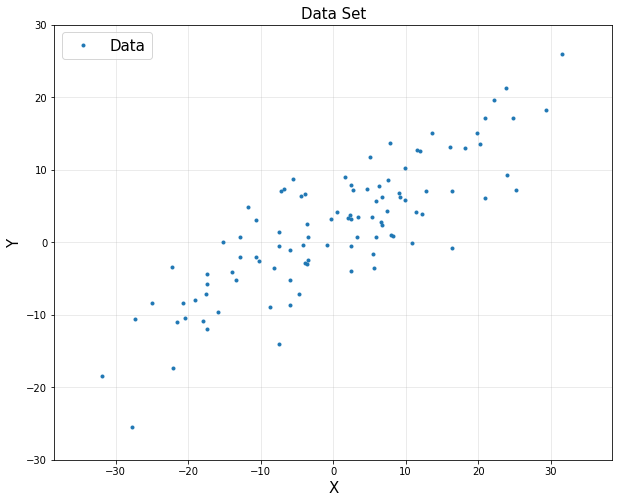

```python
import numpy as np
import matplotlib.pyplot as plt
%matplotlib inline

N = 100
w1 = 0.5
w0 = 2
x = np.random.normal(0, 15, N).reshape(-1,1)
y = w1*x + w0 + 5*np.random.normal(0, 1, N).reshape(-1,1)

plt.figure(figsize = (10, 8))
plt.title('Data Set', fontsize = 15)
plt.plot(x, y, '.', label = 'Data')
plt.xlabel('X', fontsize = 15)
plt.ylabel('Y', fontsize = 15)
plt.legend(fontsize = 15)
plt.axis('equal')
plt.axis([-40, 40, -30, 30])
plt.grid(alpha = 0.3)
plt.show()
```

```python
# here is your function for KNNReg
```

```python
# here is your code for plotting
```

# Solution 1

1) What makes KNN algorithm operate much faster than other algorithms such as SVM or linear regression

KNN is a lazy algorithm that requires no training prior to making predictions. SVM or linear regression require training of data before it can make any predictions.

2) In our class, we used the sklearn-embedded functions for k-NN. Here, you are asked to write your own function for KNN regressor.

```python
import numpy as np
import matplotlib.pyplot as plt
from scipy import stats
from collections import Counter
%matplotlib inline
```

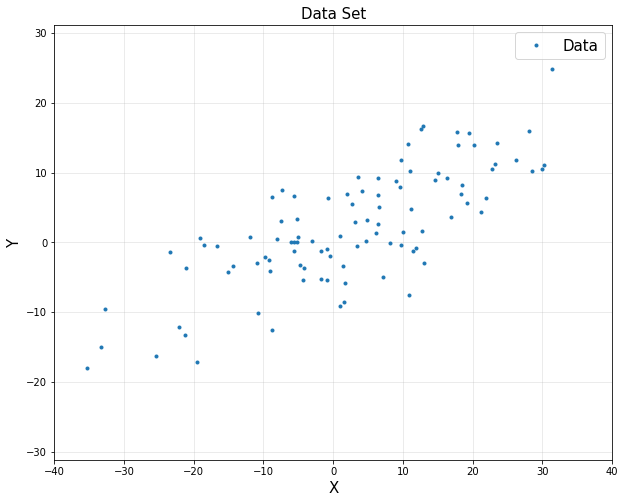

```python
N = 100
w1 = 0.5
w0 = 2
x = np.random.normal(0, 15, N).reshape(-1,1)
y = w1*x + w0 + 5*np.random.normal(0, 1, N).reshape(-1,1)

plt.figure(figsize = (10, 8))
plt.title('Data Set', fontsize = 15)
plt.plot(x, y, '.', label = 'Data')
plt.xlabel('X', fontsize = 15)
plt.ylabel('Y', fontsize = 15)
plt.legend(fontsize = 15)
plt.axis('equal')
plt.axis([-40, 40, -30, 30])
plt.grid(alpha = 0.3)
plt.show()
```

```python
data = np.hstack([x, y])
```

```python
xp = np.linspace(-30, 30, 100).reshape(-1, 1)
yp = []

for i in range(len(xp)):

    dist_and_index = []

    for j, pts in enumerate(data):
        dist = 0
        dist = np.sqrt(np.sum((np.subtract(pts[:-1], xp[i]))**2))

        dist_and_index.append((dist, j))

    sort_dist_and_index = sorted(dist_and_index)

    knn_dist_and_index = sort_dist_and_index[:1]

    knn_labels = [data[j][1] for dist, j in knn_dist_and_index]

    knn_avg = np.mean(knn_labels)

    yp.append(knn_avg)
```

## K = 1

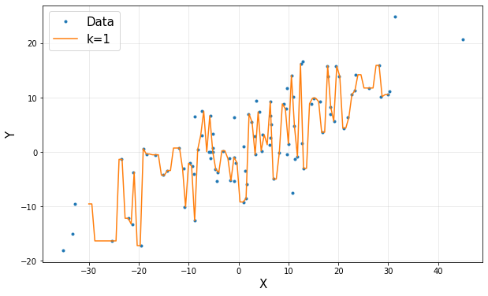

```python
plt.figure(figsize=(10, 6))
plt.plot(x, y, '.', label = 'Data')
plt.plot(xp, yp, label = 'k=1')
plt.legend(fontsize = 15)
plt.grid(alpha = 0.3)
plt.xlabel('X', fontsize = 15)
plt.ylabel('Y', fontsize = 15)
plt.show()
```

## K = 10

```python
xp = np.linspace(-30, 30, 100).reshape(-1, 1)
yp = []

for i in range(len(xp)):

    dist_and_index = []

    for j, pts in enumerate(data):
        dist = 0
        dist = np.sqrt(np.sum((np.subtract(pts[:-1], xp[i]))**2))

        dist_and_index.append((dist, j))

    sort_dist_and_index = sorted(dist_and_index)

    knn_dist_and_index = sort_dist_and_index[:10]

    knn_labels = [data[j][1] for dist, j in knn_dist_and_index]

    knn_avg = np.mean(knn_labels)

    yp.append(knn_avg)
```

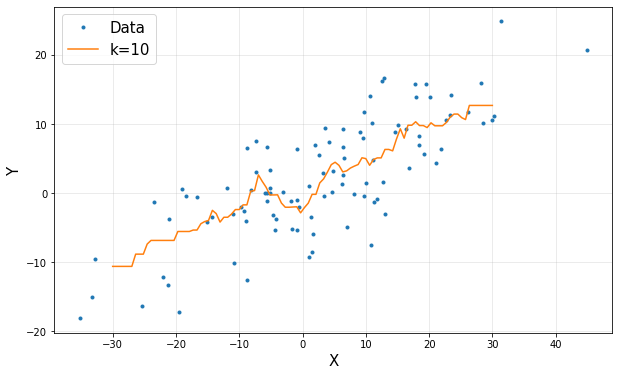

```python
plt.figure(figsize=(10, 6))
plt.plot(x, y, '.', label = 'Data')
plt.plot(xp, yp, label = 'k=10')
plt.legend(fontsize = 15)
plt.grid(alpha = 0.3)
plt.xlabel('X', fontsize = 15)
plt.ylabel('Y', fontsize = 15)
plt.show()
```

# Problem 2

In our class, we used the sklearn-embedded functions for k-NN. Here, you are asked to write your own function for KNN classification.

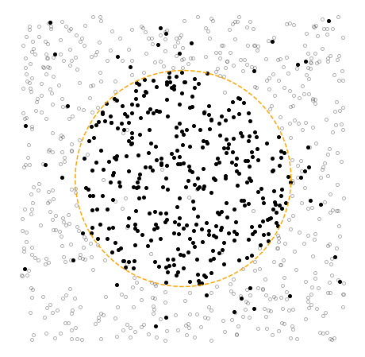

```python
m = 1000
X = -1.5 + 3*np.random.uniform(size = (m,2))

y = np.zeros([m,1])
for i in range(m):
    if np.linalg.norm(X[i,:], 2) <= 1:
        if np.random.uniform() < 0.05:
            y[i] = 0
        else:
            y[i] = 1
    else:
        if np.random.uniform() < 0.05:
            y[i] = 1
        else:
            y[i] = 0

C1 = np.where(y == 1)[0]
C0 = np.where(y == 0)[0]

theta = np.linspace(0, 2*np.pi, 100)

plt.figure(figsize = (8,8))
plt.plot(X[C1,0], X[C1,1], 'o', label = 'C1', markerfacecolor = "k", markeredgecolor = 'k', markersize = 4)
plt.plot(X[C0,0], X[C0,1], 'o', label = 'C0', markerfacecolor = "None", alpha = 0.3, markeredgecolor = 'k', markersize = 4)
plt.plot(np.cos(theta), np.sin(theta), '--', color = 'orange')
plt.axis([-1.5, 1.5, -1.5, 1.5])
plt.axis('equal')
plt.axis('off')
plt.show()
```

```python
# here is your function for KNNclf
```

```python
# here is your code for plotting
```

# Solution 2

In our class, we used the sklearn-embedded functions for k-NN. Here, you are asked to write your own function for KNN classification.

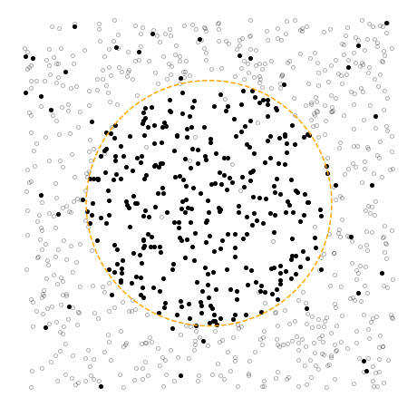

```python
m = 1000
X = -1.5 + 3*np.random.uniform(size = (m,2))

y = np.zeros([m,1])
for i in range(m):
    if np.linalg.norm(X[i,:], 2) <= 1:
        if np.random.uniform() < 0.05:
            y[i] = 0
        else:
            y[i] = 1
    else:
        if np.random.uniform() < 0.05:
            y[i] = 1
        else:
            y[i] = 0

C1 = np.where(y == 1)[0]
C0 = np.where(y == 0)[0]

theta = np.linspace(0, 2*np.pi, 100)

plt.figure(figsize = (8,8))
plt.plot(X[C1,0], X[C1,1], 'o', label = 'C1', markerfacecolor = "k", markeredgecolor = 'k', markersize = 4)
plt.plot(X[C0,0], X[C0,1], 'o', label = 'C0', markerfacecolor = "None", alpha = 0.3, markeredgecolor = 'k', markersize = 4)
plt.plot(np.cos(theta), np.sin(theta), '--', color = 'orange')
plt.axis([-1.5, 1.5, -1.5, 1.5])
plt.axis('equal')
plt.axis('off')
plt.show()
```

```python
res = 0.01
[X1gr, X2gr] = np.meshgrid(np.arange(-1.5,1.5,res), np.arange(-1.5,1.5,res))

Xp = np.hstack([X1gr.reshape(-1,1), X2gr.reshape(-1,1)])
```

```python
yp = []
for i in range(len(Xp)):
    t = np.sqrt(np.sum((np.subtract(Xp[i], X))**2, axis=1)).reshape(-1, 1)
    q = np.hstack([t, y])
    sort_p = sorted(q.tolist())
    knnCLF = sort_p[:1]
    knnCLF = np.array(knnCLF)
    knnCLF_label = knnCLF[:,1]
    yp.append(Counter(knnCLF_label).most_common(1)[0][0])
```

```python
knnCLF_label
```

```
array([0.])
```

```python
Counter(knnCLF_label).most_common(1)[0][0]
```

```
0.0
```

```python
Counter(knnCLF_label).most_common(1)[0][0]
```

```
0.0
```

```python
yp = np.array(yp)
inCircle = np.where(yp == 1)[0]
```

## K = 1

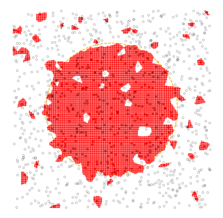

```python
plt.figure(figsize = (8, 8))
plt.plot(X[C1,0], X[C1,1], 'o', label = 'C1', markerfacecolor = "k", alpha = 0.5, markeredgecolor = 'k', markersize = 4)
plt.plot(X[C0,0], X[C0,1], 'o', label = 'C0', markerfacecolor = "None", alpha = 0.3, markeredgecolor='k', markersize = 4)
plt.plot(np.cos(theta), np.sin(theta), '--', color = 'orange')
plt.plot(Xp[inCircle][:,0], Xp[inCircle][:,1], 's', alpha = 0.5, color = 'r', markersize = 1)
plt.axis([-1.5, 1.5, -1.5, 1.5])
plt.axis('equal')
plt.axis('off')
plt.show()
```

## K = 10

```python
yp = []
for i in range(len(Xp)):
    t = np.sqrt(np.sum((np.subtract(Xp[i], X))**2, axis=1)).reshape(-1, 1)
    q = np.hstack([t, y])
    sort_p = sorted(q.tolist())
    knnCLF = sort_p[:10]
    knnCLF = np.array(knnCLF)
    knnCLF_label = knnCLF[:,1]
    yp.append(Counter(knnCLF_label).most_common(1)[0][0])
```

```python
yp = np.array(yp)
inCircle = np.where(yp == 1)[0]
```

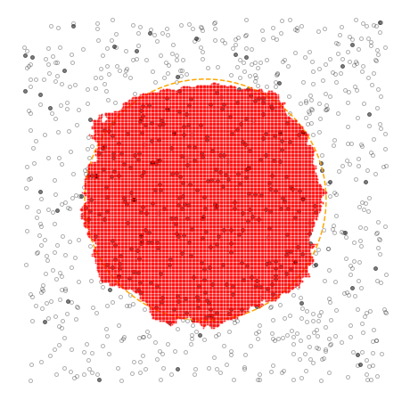

```python
plt.figure(figsize = (8, 8))
plt.plot(X[C1,0], X[C1,1], 'o', label = 'C1', markerfacecolor = "k", alpha = 0.5, markeredgecolor = 'k', markersize = 4)
plt.plot(X[C0,0], X[C0,1], 'o', label = 'C0', markerfacecolor = "None", alpha = 0.3, markeredgecolor='k', markersize = 4)
plt.plot(np.cos(theta), np.sin(theta), '--', color = 'orange')
plt.plot(Xp[inCircle][:,0], Xp[inCircle][:,1], 's', alpha = 0.5, color = 'r', markersize = 1)
plt.axis([-1.5, 1.5, -1.5, 1.5])
plt.axis('equal')
plt.axis('off')
plt.show()
```

# Problem 3

Look at the following training set for a decision tree that classifies names as either location or person names:

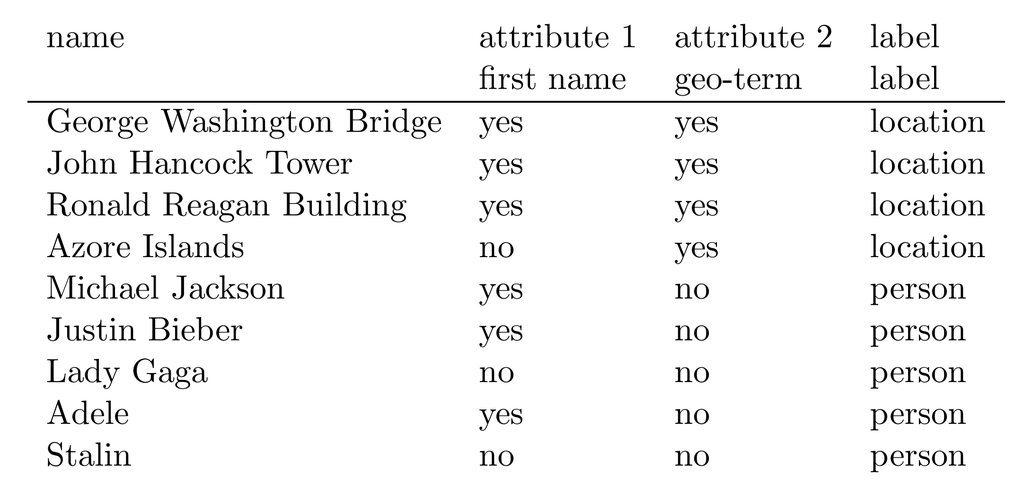

1) Calculate disorder of attribute 1.  
2) Calculate disorder of attribute 2.  
3) Which attribute is more useful, attribute 1 or attribute 2 Why?

# Solution 3

$$\begin{align*} D & = -\frac{l}{T} \log_2 \frac{l}{T} - \frac{p}{T} \log_2 \frac{p}{T} \qquad \text{where }\; l: \text{location}, \; p: \text{person},\; T: \text{Total}\\ \\ \end{align*} $$$$Q(\text{test}) = \sum D(\text{set}) \times \frac{\text{# of samples in set}}{\text{# of samples in all sets}}$$

1) Calculate disorder of attribute 1.

$$\begin{align*} D_{\text{attribute1 yes}} & = -\frac{3}{6} \log_2 \frac{3}{6} - \frac{3}{6} \log_2 \frac{3}{6} = 1\\ \\ D_{\text{attribute1 no}} & = -\frac{1}{3} \log_2 \frac{1}{3} - \frac{2}{3} \log_2 \frac{2}{3} = 0.9183 \end{align*} $$

2) Calculate disorder of attribute 2.

$$\begin{align*} D_{\text{attribute2 yes}} & = -\frac{4}{4} \log_2 \frac{4}{4} - \frac{0}{4} \log_2 \frac{0}{4} = 0\\ \\ D_{\text{attribute2 no}} & = -\frac{0}{5} \log_2 \frac{0}{5} - \frac{5}{5} \log_2 \frac{5}{5} = 0 \end{align*} $$

3) Which attribute is more useful, attribute 1 or attribute 2 Why?

$$ \begin{align*} Q_{\text{attribute1}} &= 1\times\frac{6}{9} + 0.9183\times\frac{3}{9} = 0.973\\ Q_{\text{attribute2}} &= 0\times\frac{4}{9} + 0\times\frac{5}{9} = 0\\\\ Q_{\text{attribute1}} &> Q_{\text{attribute2}}\\\\ \therefore \;&\text{attribute 2 is more useful.} \end{align*} $$